# Day 8 - Bag of Words Topic Modeling

Bryan Goodrich

January 8, 2017

# Motivation

Following yesterday’s example, we’ll continue the topic modeling as demonstrated here: http://ellisp.github.io/blog/2016/12/31/sparse-bags

### Data

https://archive.ics.uci.edu/ml/datasets/Bag+of+Words

The data is available from the UCI machine learning data sets. You can get it yourself. See below for the author’s methods for getting at the data directly.

If you’d like to get the data directly from the sources, here is the author’s code for that.

```r
# https://archive.ics.uci.edu/ml/datasets/Bag+of+Words
# download the smallest example bag of words for first trial
if(!"docword.kos.txt" %in% list.files())
{
    data_file <- "https://archive.ics.uci.edu/ml/machine-learning-databases/bag-of-words/docword.kos.txt.gz"
    download.file(data_file, destfile = "docword.kos.txt.gz", mode = "wb")
    gunzip("docword.kos.txt.gz")
}
kos_header <- c("DocId", "VocabId", "Count")
x <- read.table("docword.kos.txt", skip = 3, col.names = kos_header)
vocab <- read.table("https://archive.ics.uci.edu/ml/machine-learning-databases/bag-of-words/vocab.kos.txt")$V1
```

I work from my own file structure, so I’ll just assume you can get the data in how you want to follow along with my code below.

Here I pull in the bag of words structured data (see the UCI documentation), the vocab associated with it (each line represents the line number in the UCI file)

```r
kos_header <- c("DocId", "VocabId", "Count")
vocab <- scan("data/vocab.kos.txt", what = "")
x <- read.table("data/docword.kos.txt", skip = 3, col.names = kos_header)
x$Word <- vocab[x$VocabId]
x$Word <- wordStem(x$Word)

x <- x %>% group_by(DocId, Word) %>% summarise(Count = sum(Count))    # Dense
y <- reshape2::dcast(x, DocId ~ Word, value.var = "Count", fill = 0)  # Sparse DTM
y$DocId <- NULL  # Column not needed; each row is its DocId
exclude <- which(nchar(colnames(y)) > 20)
y <- y[, -exclude]
```

Here we run through fitting a model of size k = 5. I could set up a loop (lapply) to produce a number of models to compare, but in keeping consistent with yesterday, I’ll just stick to a 5 topic model. Since it is still a time consuming process even for one model, I’ll save the results and use them afterwards.

```r
lda <- LDA(y, 5)
saveRDS(lda, file = "data/kos_topics.Rds", compress = 'xz')
```

# Wordcloud

Not a large change from the clustering method yesterday. Basically pull the top 100 sorted (descending) words from each topic in the model. These are accessible from the terms matrix when you run `posterior` on your LDA object.

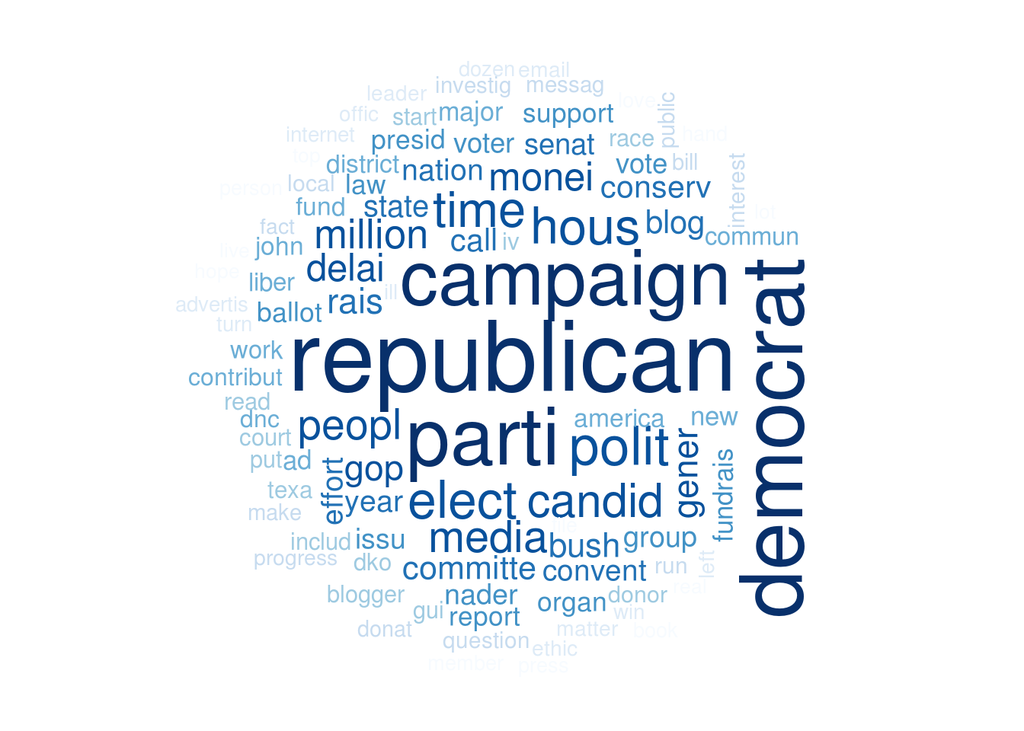

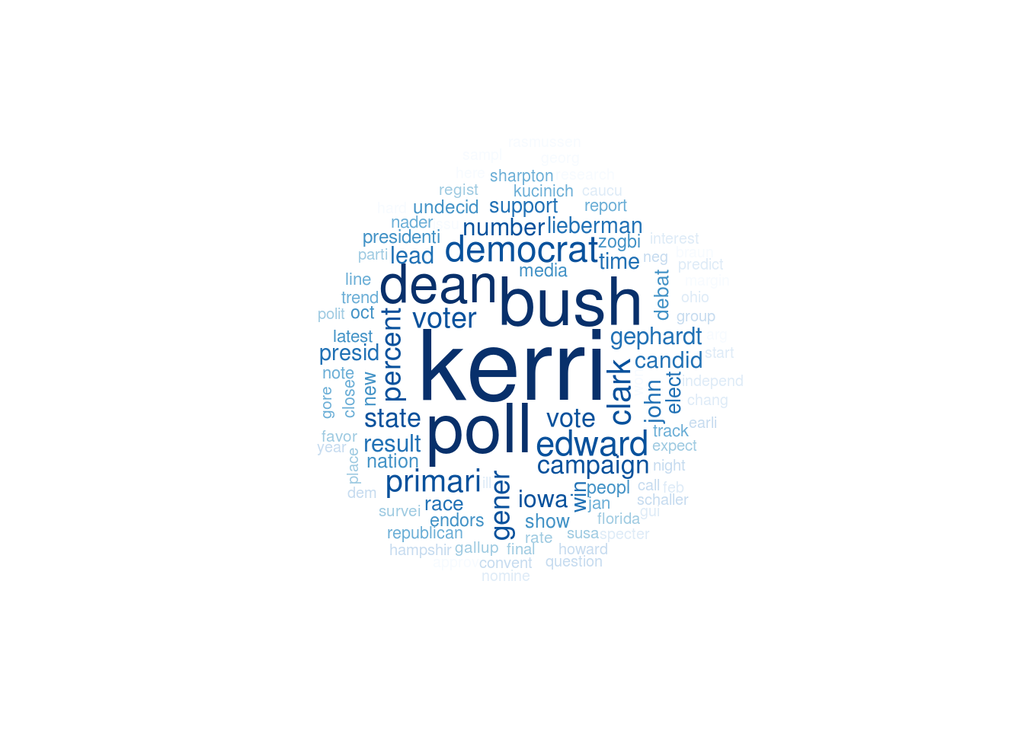

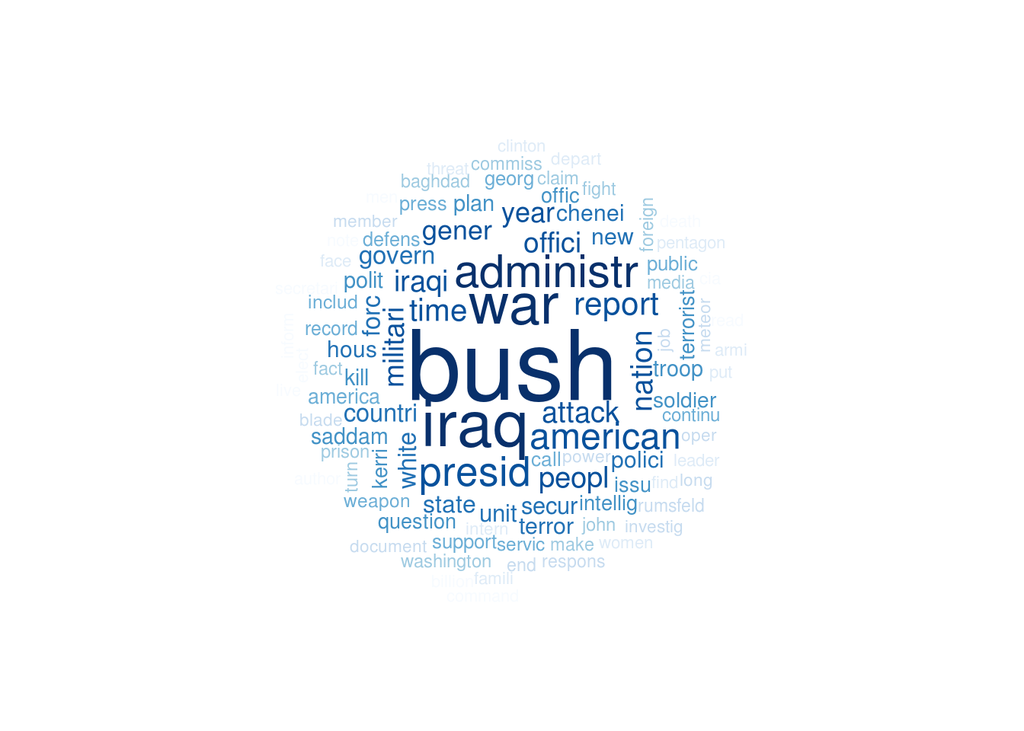

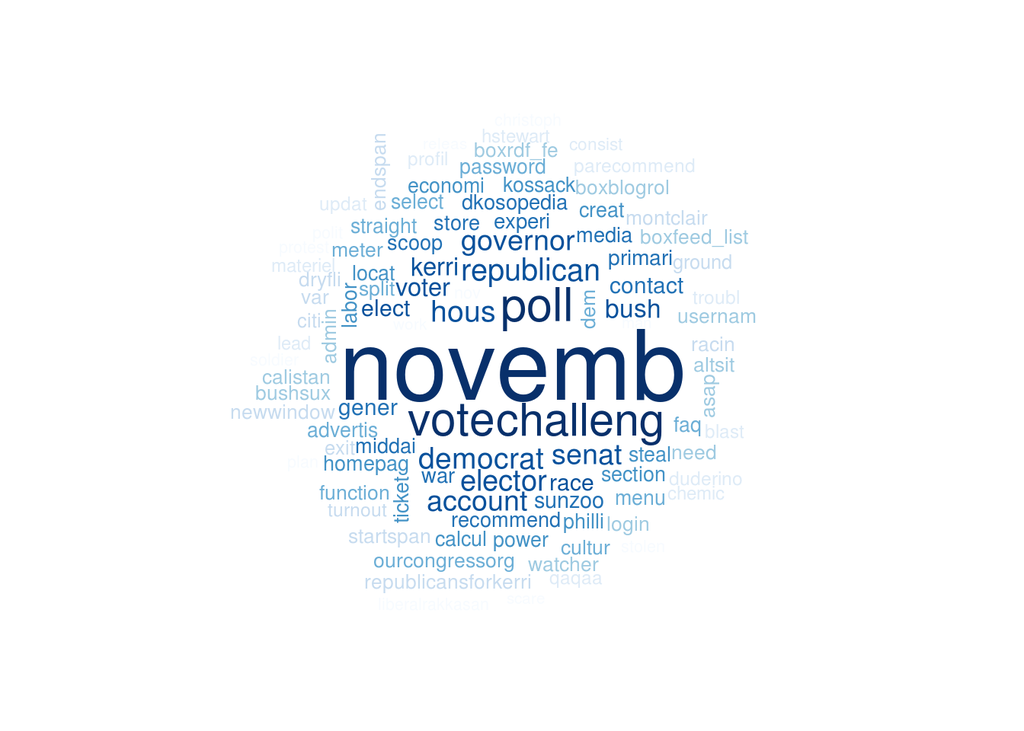

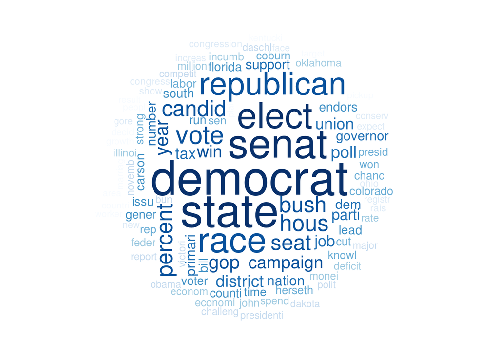

```r
# A convenience closure
topN <- function(N=100) function(k, terms) head(sort(terms[k, ], TRUE), n = N)

lda <- readRDS("data/kos_topics.Rds")

k=5
h <- 100 # how many top words to put in the cloud
p <- lapply(1:k, topN(h), terms = posterior(lda)$terms)

pal <- rep(brewer.pal(9, "Blues"), each = ceiling(h / 9))[h:1]
for (n in 1:k)
{
    wordcloud(
        names(p[[n]]), freq = p[[n]], min.freq=0, random.order = FALSE,
        ordered.colors = TRUE, colors = pal
    )
}
```

### Closing Remarks

This had similar but more clear topics than the clustering method, at least to me. anything, I think I see topics like

1. The campgains
2. Kerri and the polls
3. Bush administration and the Iraq war
4. The November vote
5. Democrats and the senate race

How good are these? No idea, but like before this would need a lot more vetting. I’d also want to consider td-idf weights in both cases. Fun stuff, and very easy to setup having done it again. For another example, see my [Twitter Topic Modeling](https://gist.github.com/bryangoodrich/7b5ef683ce8db592669e).